# IMDB Movies

# Quels genres préfèrent t'on ?

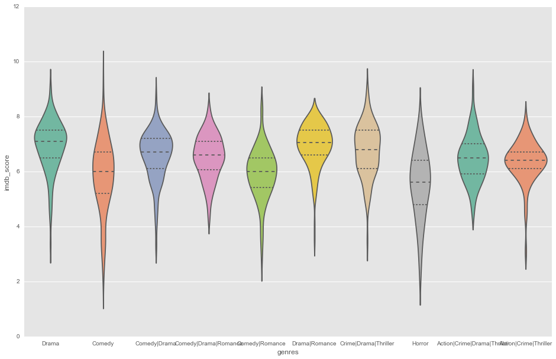

```python
ax = sns.violinplot(x="genres", y="imdb_score",
        data=movies, palette="Set2", split=True,order= list(movies.genres.value_counts().head(10).index),
        scale="area", inner="quartile")
```

```python
movies.groupby("genres").agg({"imdb_score":"mean","count":"count"}).sort_values("imdb_score", ascending=False).head(5)
```

| genres | imdb_score | count |
| --- | --- | --- |
| Action\|Adventure\|Crime\|Drama\|Sci-Fi\|Thriller | 8.8 | 1 |
| Action\|Adventure\|Biography\|Drama\|History | 8.6 | 1 |
| Crime\|Drama\|Fantasy\|Mystery | 8.5 | 1 |
| Adventure\|Animation\|Drama\|Family\|Musical | 8.5 | 1 |
| Action\|Drama\|History\|Thriller\|War | 8.5 | 1 |

# Comment prédire le score IMDB

On voit assez bien que les notes sont plutot au dessus de la moyenne. On peut maintenant essayer de voir si on peut trouver une corrélation entre le nombre de like de chaque acteur et la note attribuée.

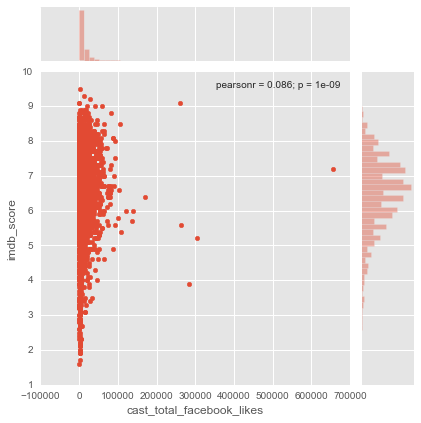

```python
sns.jointplot(x="cast_total_facebook_likes", y="imdb_score", data=movies);
```

On voit ici que les données sont très écrasées autours de 0. On voit quelques points qu'on peut nommés d'outliers ce qui veut dire qu'ils sont vraiment éloignés de la plupart des autres points de l'échantillions.  
Pour cela nous avons plusieurs solutions, les plus faciles à mettre en oeuvre sont de les enlever tout simplement ou d'appliquer un logarithme sur la variable en question. On sait par contre que le log n'est défini que sur ]0;+inf[ il faut prendre en compte cela dans sa mise en place.

```python
movies["cast_total_facebook_likes_log"] = movies["cast_total_facebook_likes"].apply(lambda x : math.log(x) if x!=0 else x)
```

Si on réaplique le log sur cette nouvelle variable créée

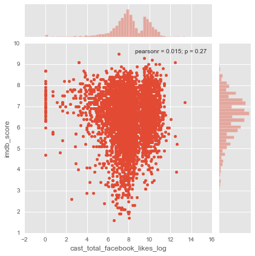

```python
sns.jointplot(x="cast_total_facebook_likes_log", y="imdb_score", data=movies);
```

On voit que le nuage de point, ainsi que l'histograme ne sont plus écrasés en 0 mais nous ne pouvons malheuresement pas tiré de conclusions sur la création du score en fonction du nombre de likes de l'équipe du tournage.